# EV1216

Qi Huang

12/16/2019

This project is to explore the electric charging station conditions in United States. Four main questions are investigated in this project. 1. The current number of charging stations in California and United States 2. If there are sufficient restaurants around the charging station and the distance between these two spots 3. The demand and the supply of the charging station 4. Opinions about the charging station (text mining of an article)

Summary of the content 1. EDA on existing charging stations 2. Number of charging stations (Mapping) 3. Restaruant around charging stations 4. Growth rate of the electric vehicles and growth rate of the charging stations 5. Opinions about the charging station

DATA ACQUISITION Data are gathered from three sources: U.S. Department of Energy, Yelp data, research paper.

```r
#NY charging station
df <- read.socrata(
  "https://data.ny.gov/resource/bpkx-gmh7.json",
  app_token = "LK05q1lMNPWAqZ7My1YlIGCkr",
  email     = "hayleyformer@gmail.com",
  password  = "Hailey07#"
)
#California charging station
url <-"https://developer.nrel.gov/api/alt-fuel-stations/v1.json?fuel_type=ELEC&state=CA&api_key=UI8ftsbXoXhViwIMWdzStMcwdpyZPqyhHBOpv5sP"
df1 <- jsonlite::fromJSON(url,simplifyDataFrame = TRUE,flatten = TRUE)
df1 <- df1$fuel_stations
df <- df %>% distinct()

#All states charging station
url2 <-"https://developer.nrel.gov/api/alt-fuel-stations/v1.json?fuel_type=ELEC&state=all&api_key=UI8ftsbXoXhViwIMWdzStMcwdpyZPqyhHBOpv5sP"
df2 <- jsonlite::fromJSON(url2,simplifyDataFrame = TRUE,flatten = TRUE)
df2 <- df2$fuel_stations

#percent share of US EV sales by State
g <- readxl::read_xlsx("Percent share of US EV Sales by State.xlsx")
#Yelp data
devtools::install_github("OmaymaS/yelpr")
library(yelpr)
yelp_long <- head(df$longitude,10)
yelp_lat <- head(df$latitude,10)
location <- as.data.frame(cbind(yelp_long,yelp_lat))
key <- "QOk02yFuAi8h5EBi-4eq1VO88CYP_pCw-kyej_XDucODNmTPOsqubieFDm0hmLqM16sjksD8aVEHuw4F00GWoIl9tavU7T4LmRRm2wob9rJVQZ1RYcNQCAKhVRX3XXYx"
yelpdata1 <- business_search(api_key = key, longitude = yelp_long[1], latitude = yelp_lat[1])
```

```
## No encoding supplied: defaulting to UTF-8.
```

```r
yelpdata1 <- as.data.frame(yelpdata1)
```

DATA CLEANING

1. EDA on existing charging stations 1.1 fuel type

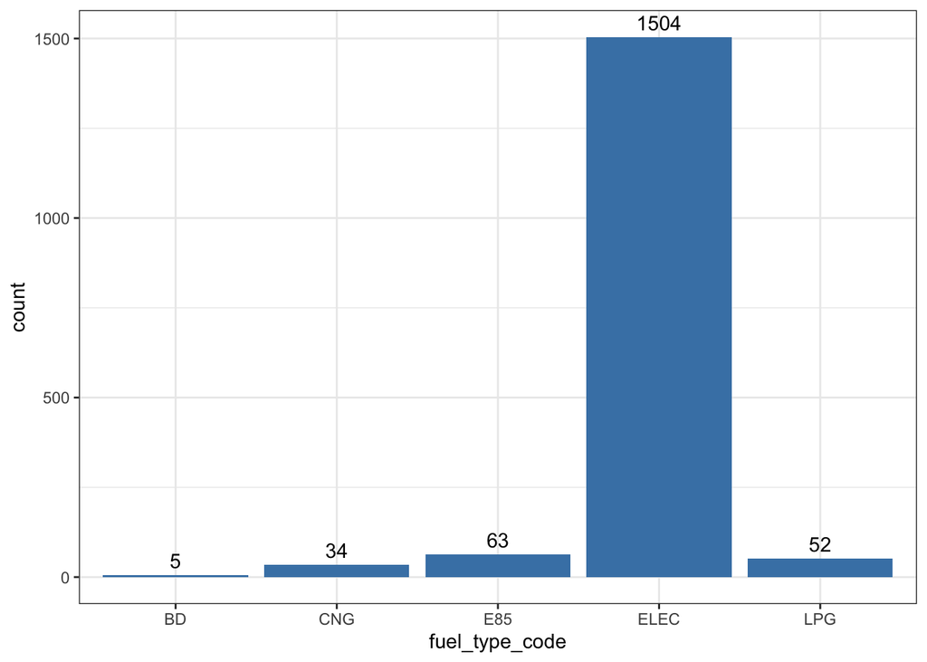

```r
#1.1 fuel type
plot1 <- df %>% ggplot(aes(x=fuel_type_code))+
                         geom_bar(fill = "steelblue")+
  geom_text(stat = 'count',aes(label = ..count..),vjust=-.5)+
  theme_bw()
plot1
```

Most file types are electric supply.

1.2 access time

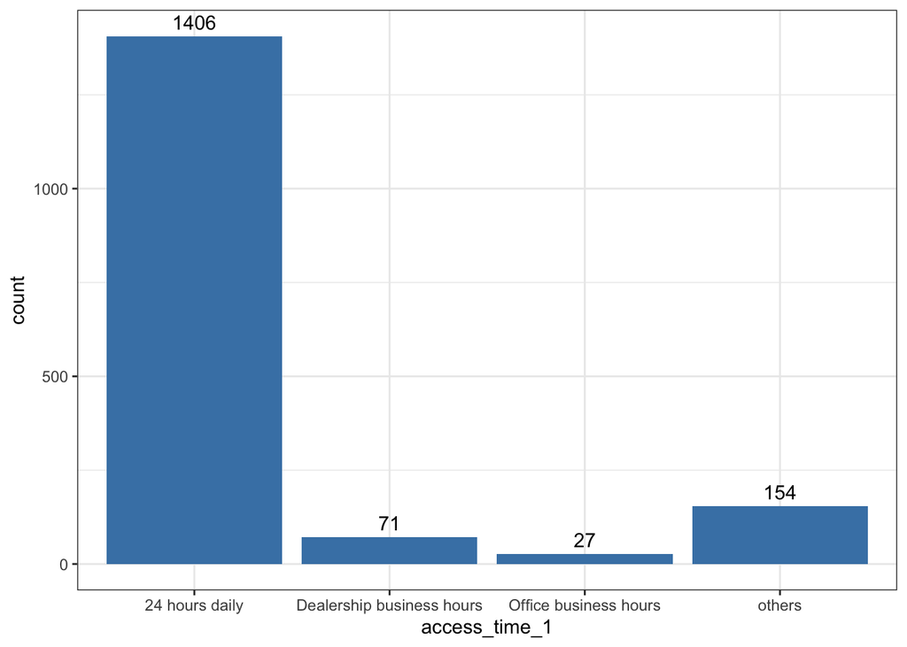

```r
#1.2 access time
plot2 <- df %>% ggplot(aes(x=access_time_1))+
  geom_bar(fill = "steelblue")+
  geom_text(stat = 'count',aes(label = ..count..),vjust=-.5)+
  theme_bw()
plot2
```

Most of the charging stations are 24 hours.

1.3 facility type

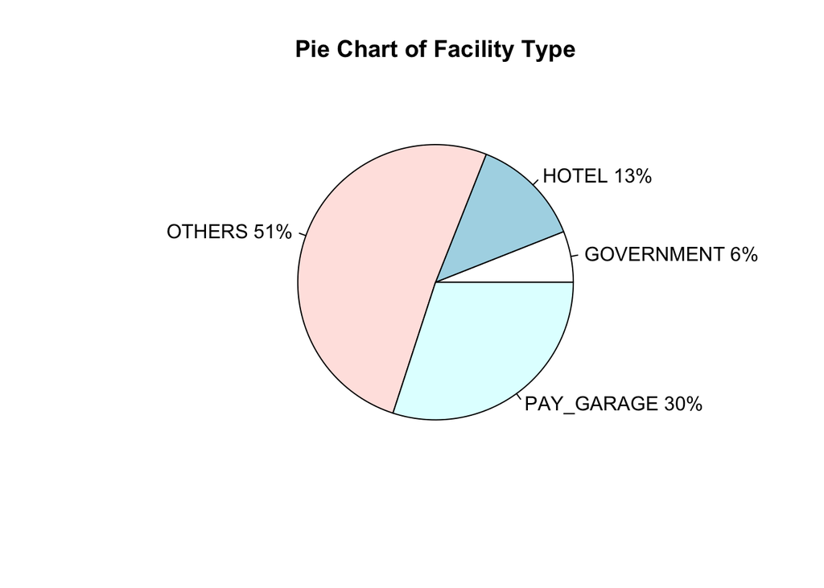

```r
#1.3 facility type
fac <- as.data.frame(df$facility_type_1)
fac <- na.omit(fac)
names(fac) <- "facility"
slices <- fac %>% group_by(facility) %>% summarise(n())
names(slices) <- c("facility","count")
lbls <- c("GOVERNMENT","HOTEL","OTHERS","PAY_GARAGE")
pct <- round(slices$count/sum(slices$count)*100)
lbls <- paste(lbls,pct)
lbls <- paste(lbls,"%",sep="")
plot3 <- pie(pct,labels = lbls,main = "Pie Chart of Facility Type")
```

Facility type is important for analyzing if the charging station would have enough supporting facilities such as food and water. For example, hotel usually has efficient infrastructure that provides convinience. However, based on the pie chart, more than half of the charging stations are run by “others”, meaning that the from this plot we can not recognize if the infrastructures around charging stations are efficient.

2. Number of charging stations (Mapping)  
   2.1 U.S. state map with numbers of charging stations

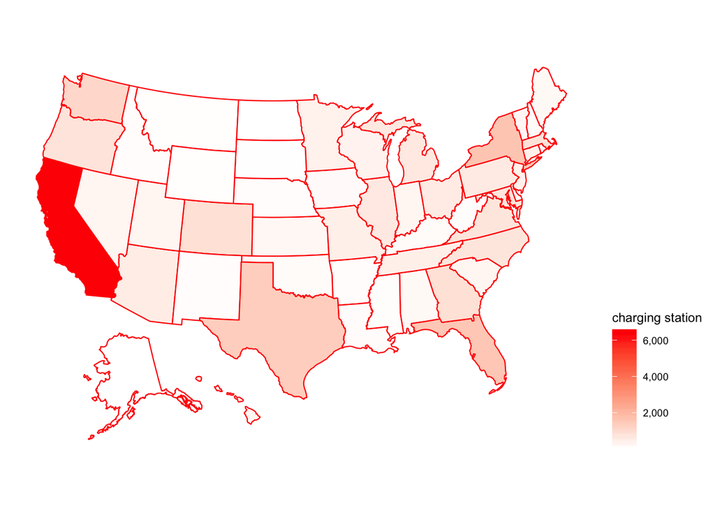

```r
#U.S. state map with numbers of charging stations
number <- df2 %>% group_by(state) %>% summarise(n())
colnames(number) <- c("state","number")
map1 <- plot_usmap(data = number,values = "number",color = "red")+
  scale_fill_continuous(
    low = "white", high = "red", name = "charging station", label = scales::comma)+
  theme(legend.position = "right")
map1
```

2.2 New York charging station

```r
#New York charging station
map2 <- leaflet(df) %>% addTiles() %>%
  addMarkers(~as.numeric(longitude),~as.numeric(latitude))
map2
```

[interactive chart not shown]

2.3 california charging station

```r
#CA charging station
map3 <- leaflet(df1) %>% addTiles() %>%
  addMarkers(~as.numeric(longitude),~as.numeric(latitude))
map3
```

[interactive chart not shown]

2.4 All states charging station with clustering

```r
#All states charging station with clustering
map4 <- leaflet(df2) %>% addTiles() %>% addMarkers(
  clusterOptions = markerClusterOptions()
)
```

[output not shown]

```
## Assuming "longitude" and "latitude" are longitude and latitude, respectively
```

2.5 charging station only for Tesla

```r
# charging station only for Tesla
tesla <- df %>% filter(str_detect(access_days_time,"Tesla"))
non_tesla <- df %>% filter(!str_detect(access_days_time,"Tesla"))
icons_tesla <- awesomeIcons(
  icon = 'ios-close',
  iconColor = 'black',
  library = 'ion',
  markerColor = "green"
)
icons_all <- awesomeIcons(
  icon = 'ios-close',
  iconColor = 'black',
  library = 'ion',
  markerColor = "red"
)
map5 <- leaflet() %>% addTiles() %>%
  addAwesomeMarkers(data = tesla,lng = ~as.numeric(longitude),lat = ~as.numeric(latitude),group = "Tesla - Only",icon = icons_tesla)%>%
  addAwesomeMarkers(data = non_tesla,lng = ~as.numeric(longitude),lat = ~as.numeric(latitude),group = "For - All",icon = icons_all)

map5%>%addLayersControl(overlayGroups = c("Tesla - Only","For - All"),options = layersControlOptions(collapsed = FALSE))%>%hideGroup("For - All")
```

[interactive chart not shown]

Based on the data description, some charging stations are only for Tesla. Therefore, this map is about positioning the charging stations that are only applied for Tesla.

3. Restaruant around charging stations  
   3.1 Positions of restarurants around the charging station shown as CAT.

```r
#Connected with YELP data
yelpdata1$businesses.coordinates
```

```
##    latitude longitude
## 1  40.70844 -73.94078
## 2  40.71503 -73.94767
## 3  40.70504 -73.93357
## 4  40.70601 -73.93260
## 5  40.70774 -73.94020
## 6  40.71066 -73.95887
## 7  40.72609 -73.95231
## 8  40.71725 -73.94485
## 9  40.71745 -73.94503
## 10 40.70759 -73.93327
## 11 40.71553 -73.94427
## 12 40.71516 -73.94645
## 13 40.71842 -73.95743
## 14 40.71711 -73.94061
## 15 40.71975 -73.95999
## 16 40.71485 -73.95466
## 17 40.70504 -73.92808
## 18 40.71407 -73.95633
## 19 40.71056 -73.92340
## 20 40.72372 -73.95160
```

```r
map6 <- leaflet(yelpdata1$businesses.coordinates) %>% addTiles() %>%
  addMarkers(~as.numeric(longitude),~as.numeric(latitude)) %>%
  addMarkers(lng =  -73.932309, lat =   40.718037, icon = list(
    iconUrl = "https://img.icons8.com/pastel-glyph/64/000000/cat--v3.png",
    iconSize = c(75, 75)
  ))
map6 #the place with the cat icon is the charging station.
```

[interactive chart not shown]

Yelp data is connected with the U.S. Department of Energy data. The cat icon is one of the charging stations in New York, and restaruant around this charging station are plotted in the map.

3.2 Distance of those restaurants with the charging station

```r
#distances between the charging station and the resutaurants around
p1 <- yelpdata1$businesses.coordinates
p2 <- as.data.frame(cbind(rep(40.718037,20),rep(-73.932309,20)))
distance <- as.data.frame(geosphere::distHaversine(p1,p2))
colnames(distance) <- "distance for charging station CAT"
summary(distance)
```

```
##  distance for charging station CAT
##  Min.   : 339.3
##  1st Qu.: 931.8
##  Median :1406.5
##  Mean   :1573.0
##  3rd Qu.:2302.5
##  Max.   :3082.2
```

Based on the results, the nearest restaruant is only 340 meters away from the charging station, and the median distance is 1407 meters. The result indicats that it is not hard to find food around the charging station.

4. Growth rate of the electric vehicles and growth rate of the charging stations

```r
#Growth rate of the electric vehicles
g[,6] <- g[,4]/g[,2] - 1
colnames(g)[6] <- "growth"
g$growth
```

```
##  [1]  0.61734108  0.56114965  0.78975665  1.08504488  1.17088024
##  [6]  0.83389628  0.94084629  0.69658325  0.49849549  0.92995803
## [11]  0.81201435  0.94173859  1.38104839  1.17428377  0.30233406
## [16]  1.47383601  0.48220486  1.13103778  1.29294404  0.18717684
## [21]  0.24111675  1.04077253  0.97334480  0.97217391  1.17696629
## [26]  1.18220793 -0.05396096  1.52085967  0.42512690  2.88277858
## [31]  1.08185053  0.72198276  1.08628319  1.11778291  0.42956120
## [36]  0.56359102  0.91206030  1.27296588  0.91056911  1.18611111
## [41]  1.16607774  1.41538462  1.06224066  1.32620321  0.91608392
## [46]  0.80468750  0.92920354  0.82352941  0.70886076  0.80392157
## [51]  1.43589744  0.74544778
```

Growth rate of the electric vehicles Based on the results, the overall growth rate for electric vehicles in all states is 74%. Grwoth rate of the charging station As mentioned in the research paper (source:https://theicct.org/sites/default/files/publications/US_charging_Gap_20190124.pdf), the charging infrastructure increased by 36%–46% across these charging types for the same 100 markets from 2016 to 2017. Compared the two growth rate, it seems that the number of electric vehicles grow much more rapidly (200%) than the number of charging station, which indicates that the supply of the charging stations might not meed the demand of hte charging stations.

5. Opinions about the charging station Text mining is applied to explore the opinions about the charging station using one research article. Wordcloud, sentiment analysis and emotion text analysis are conducted. 5.1 frequency of words using Wordcloud

[output not shown]

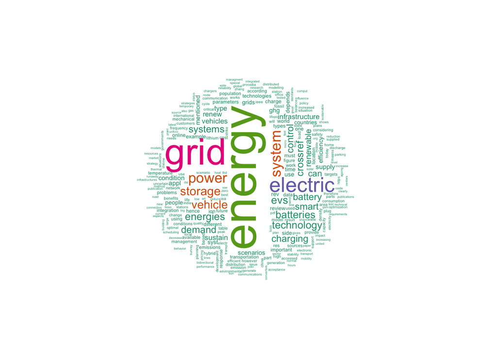

```r
#frequency of words
word_cloud <- unlist(clean_text)
tm1 <- wordcloud(word_cloud,min.freq = 5,random.order = FALSE,rot.per = 0.2,
                 colors = brewer.pal(5,"Dark2"),scale = c(4,0.2))
```

```r
tm1
```

5.2 sentiment analysis

```r
#sentiment analysis
sent <- analyzeSentiment(text,language = "english")
sent <- as.data.frame(sent[,1:4])
head(sent)
```

```
##   WordCount SentimentGI NegativityGI PositivityGI
## 1         1           0            0            0
## 2         1           0            0            0
## 3         5           0            0            0
## 4         3           0            0            0
## 5         6           0            0            0
## 6         0         NaN          NaN          NaN
```

```r
summary(sent$SentimentGI)
```

```
##     Min.  1st Qu.   Median     Mean  3rd Qu.     Max.     NA's
## -1.00000  0.00000  0.00000  0.07234  0.16667  1.00000       55
```

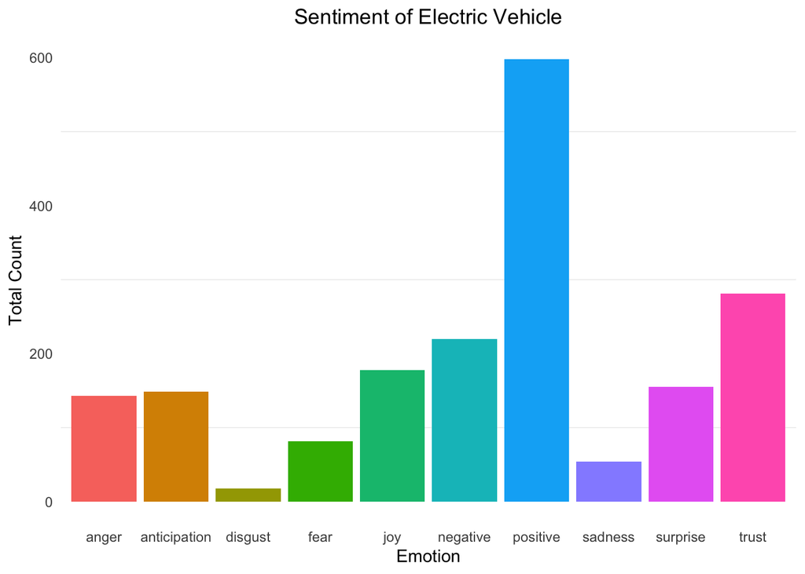

```r
sent2 <- get_nrc_sentiment(text)
sent3 <- as.data.frame(colSums(sent2))
sent3 <- rownames_to_column(sent3)
colnames(sent3) <- c("emotion","count")
tm2 <- ggplot(sent3, aes(x = emotion, y = count, fill = emotion)) +
  geom_bar(stat = "identity") + theme_minimal() +
  theme(legend.position="none",
        panel.grid.major = element_blank()) + labs( x = "Emotion", y = "Total Count") +
  ggtitle("Sentiment of Electric Vehicle") + theme(plot.title = element_text(hjust=0.5))
tm2
```

Based on the result of the sentiment analysis, most people are positive to the charging station condition.However, there are still a number of people that feel anger, fear or negative about the charging station condition.